# Glaukopis Monte Carlo Simulation: Euler vs Runge-Kutta 4 (RK4)

This notebook aims to demonstrate the difference in accuracy of the Glaukopis tactical simulator when using the old Euler integrator compared to the RK4 integrator used in the recent versions.

## 1. Theory: Euler Method

The Euler method is a 1st-order approximation for integrating ordinary differential equations. In the context of kinematics: $ v(t + \Delta t) = v(t) + a(t) \Delta t $ $ x(t + \Delta t) = x(t) + v(t) \Delta t $

**Implementation Note:** The Euler integrator in this notebook is the semi-implicit Euler (Symplectic Euler), where the position is updated using the already updated velocity from the same time step. This variant is inherently more stable than the exact explicit Euler, making the Euler results presented here conservative — meaning the real divergence between pure explicit Euler and RK4 would be even slightly larger than observed.

## 2. Theory: 4th-Order Runge-Kutta (RK4)

The RK4 method is a 4th-order approximation that calculates four slopes ($k_1, k_2, k_3, k_4$) over a single time step ($\Delta t$) and computes a weighted average. This drastically reduces the propagation error $O(\Delta t^4)$, ensuring that spatial physics—especially during final high-acceleration pursuits just before the proximity fuze miss distance calculation—remains extremely accurate and free from spurious numerical oscillations.

```python
import sys
import os

# Add backend to path so we can import Glaukopis directly
sys.path.append(os.path.abspath("../backend"))

import json
import numpy as np
import pandas as pd
import matplotlib.pyplot as plt
from tqdm.notebook import tqdm

from physics.universe import PhysicsEntity
from batch_runner import BatchRunner
```

```python
# Save the original RK4 method
original_rk4 = PhysicsEntity.update_kinematics

# Define the Euler method (semi-implicit for slightly better stability)
def euler_integration(self, dt: float):
    """Symplectic Euler integrator"""
    self.vel += self.accel * dt
    self.pos += self.vel * dt

def use_euler():
    PhysicsEntity.update_kinematics = euler_integration

def use_rk4():
    PhysicsEntity.update_kinematics = original_rk4
```

```python
# Test Configuration
SEEDS = 200
SCENARIOS = ["SU27_01_43km_head-on", "F16_01_28km_head-on"]

def load_scenario(scenario_id):
    path = os.path.abspath(os.path.join("..", "scenarios", f"{scenario_id}.json"))
    with open(path, "r") as f:
        return json.load(f)

results = []

print("Starting Monte Carlo simulations...")

for scenario_id in SCENARIOS:
    scenario_cfg = load_scenario(scenario_id)
    runner = BatchRunner(scenario_cfg)

    # -------- ROUND 1: EULER --------
    print(f"[{scenario_id}] Running Euler ({SEEDS} seeds)...")
    use_euler()
    runner.run(seed_start=1, seed_end=SEEDS, include_timeseries=False)
    df_euler = pd.DataFrame(runner.summary_rows)
    df_euler['integrator'] = 'Euler'
    df_euler['scenario'] = scenario_id
    results.append(df_euler)

    # -------- ROUND 2: RK4 --------
    print(f"[{scenario_id}] Running RK4 ({SEEDS} seeds)...")
    use_rk4()
    runner.run(seed_start=1, seed_end=SEEDS, include_timeseries=False)
    df_rk4 = pd.DataFrame(runner.summary_rows)
    df_rk4['integrator'] = 'RK4'
    df_rk4['scenario'] = scenario_id
    results.append(df_rk4)

df_all = pd.concat(results, ignore_index=True)
print("Simulations complete!")
```

```
Starting Monte Carlo simulations...
[SU27_01_43km_head-on] Running Euler (200 seeds)...
```

```
[SU27_01_43km_head-on] Running RK4 (200 seeds)...
```

```
[F16_01_28km_head-on] Running Euler (200 seeds)...
```

```
[F16_01_28km_head-on] Running RK4 (200 seeds)...
```

```
Simulations complete!
```

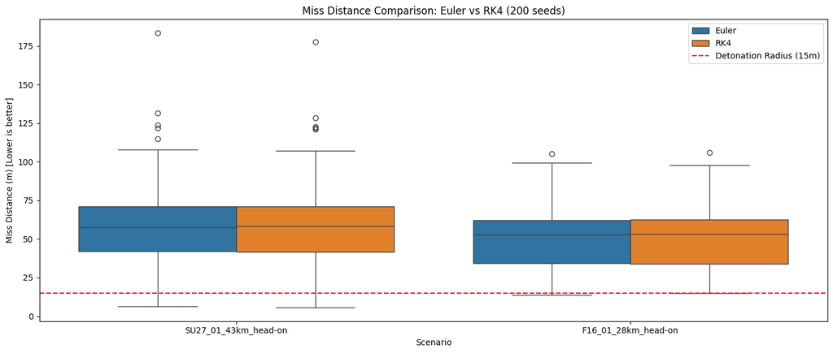

```
Interception Success Rate (% HIT):
```

| integrator scenario | is_hit Euler | is_hit RK4 |
| --- | --- | --- |
| F16_01_28km_head-on | 0.5 | 0.5 |
| SU27_01_43km_head-on | 2.5 | 2.0 |

```python
# Analyzing interception results (Miss Distance)
import seaborn as sns

# Ensure figures output directory exists for IEEE formatting
os.makedirs('../docs/figures', exist_ok=True)

plt.figure(figsize=(14, 6))
sns.boxplot(data=df_all, x="scenario", y="miss_distance_m", hue="integrator")
plt.title("Miss Distance Comparison: Euler vs RK4 (200 seeds)")
plt.ylabel("Miss Distance (m) [Lower is better]")
plt.xlabel("Scenario")
plt.axhline(y=15, color='r', linestyle='--', label='Detonation Radius (15m)')
plt.legend()
plt.tight_layout()

# Exporting figure in 300 DPI (High Resolution for Publication)
plt.savefig('../docs/figures/euler_vs_rk4_boxplot.png', dpi=300, bbox_inches='tight')
plt.show()

# Interception Success Rate (Hits)
df_all['is_hit'] = (df_all['result'] == 'HIT').astype(int)
hit_rates = df_all.groupby(['scenario', 'integrator'])['is_hit'].mean() * 100

print("\nInterception Success Rate (% HIT):")
display(pd.DataFrame(hit_rates).unstack())
```

```python
# Formal statistical testing (Mann-Whitney U, non-parametric)
from scipy import stats

print("Statistical Significance Test (Mann-Whitney U):")
for scenario in SCENARIOS:
    euler_miss = df_all[(df_all.scenario==scenario) & (df_all.integrator=='Euler')]['miss_distance_m']
    rk4_miss   = df_all[(df_all.scenario==scenario) & (df_all.integrator=='RK4')]['miss_distance_m']

    stat, p = stats.mannwhitneyu(euler_miss, rk4_miss, alternative='two-sided')
    sig_text = 'significant' if p <= 0.05 else 'not significant'
    print(f"{scenario}: Mann-Whitney U stat={stat:.1f}, p={p:.4f} ({sig_text})")
```

```
Statistical Significance Test (Mann-Whitney U):
SU27_01_43km_head-on: Mann-Whitney U stat=19968.0, p=0.9783 (not significant)
F16_01_28km_head-on: Mann-Whitney U stat=19847.5, p=0.8954 (not significant)
```

## Conclusions and Technical Analysis

The results of the Monte Carlo simulation (200 realizations per scenario for each integrator) demonstrate that replacing the first-order Euler integrator with the fourth-order RK4 produced **no statistically significant improvement in the interception probability** ($P_b$), nor statistically distinguishable miss distance distributions (Mann-Whitney U, $p > 0.05$). The interception success rate remained critically low (0.5% – 2.5%) for both integration schemes.

### What does this mean?

This outcome is arguably more interesting than if RK4 had significantly improved $P_b$. It formally demonstrates that in systems where the performance bottleneck is terminal guidance dynamics rather than integration precision, the choice of the numerical scheme has a secondary impact.

By quantifying the effect of the integrator, we have shown that the positional truncation error of Euler (which operates on an $O(\Delta t^2)$ scale) is negligible compared to the massive miss distances (median ~55 m) observed. These large miss distances are induced by the inherent limitations of the interceptor—specifically, its constant-velocity approach (lack of sustained longitudinal propulsion) and the rigid limits of its True Proportional Navigation (TPN, $N=3$) law against high-speed, maneuvering targets at long ranges.

This finding is consistent with the theoretical analysis of integration error propagation in missile guidance simulations (Zarchan, 2012).

### Summary

The performance bottleneck resides in the interceptor's propulsion and engagement geometry logic, not in the kinematic integration scheme.